# Hizkuntzalaritza

Hizkuntzaren Didaktika

Hizkuntzalaritzaren inguruko oinarritxoak

oinarritxo ñimiñoak

### Zer da Hizkuntzalaritza?

- Hizkuntzak eta hauekin zerikusia dituzten fenomenoak aztertzen dituen zientzia.
- Hizkuntzak sistema bat bezala funtzionatzen du. Sistema horren barruan fonetika eta fonologia, morfosintaxia, lexikologia, semantika, pragmatika daude.
- Hizkuntzen jabekuntza
- Hizkuntzalaritza antropologikoa
- Soziolinguistika
- Psikolinguistika
- Neurolinguistika
- Hizkuntzalaritza historikoa edo konparatua
- Korpusaren hizkuntzalaritza
- Hizkuntzalaritza konputazionala
- Hizkuntzalaritza aplikatua
- …

### Zer izan behar dugu kontuan hizkuntza bat ikasterakoan?

Eragiten duten elementuak asko direla esan ohi da, ikertuenak hauek dira:

- **Arreta**: askotan hizkuntza bat ikasten dugunean ez ditugu gauza asko kontuan izaten… (klasean ariketa laburra)
- **Filtro afektiboak** (motibazioa tartean)
- **Kanpoko eta barneko faktoreak**…

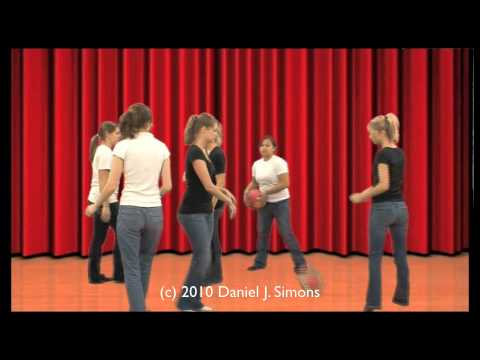

https://www.youtube.com/shorts/8fevFTOMW5s

### Filtro afektiboa?

- Filtro afektiboa L2 jabekuntza/ikaste prozesua ulertzeko teoria bat da, eta L2 bat jabetzeko/ikasteko arrakasta edo hutsegitearekin lotutako aldagai emozionalak azaltzen ditu.
- Filtro psikologiko ikustezina da eta L2 jabekuntza/ikaste prozesua erraztu edo oztopatu dezake.
- Filtro afektiboa altua denean, ikasleak estresa, antsietatea edo konfiantza eza esperimentatu ahal ditu, eta honek L2 jabekuntza/ikaste prozesuaren arrakasta eragotzi dezake. Filtro afektiboa baxua denean L2 praktikatzeko eta ikasteko jarrera positiboa eta arriskutsu bat (beldur barik) errazten du.

## Hausnarketa

- 1. Filtro afektiboa kontuan hartuta, zer nolako esperientzia izan duzu beste hizkuntzak ikasterakoan?
- 2. Zer egin dezakegu filtro afektiboa txikiagotzeko?

### Hizkuntzaren atal nagusiak

- Semantika
- Pragmatika
- Morfologia
- Sintaxia
- Fonetika
- Fonologia
- …

### Semantika eta Pragmatika

## Semantika

Zeinu linguistikoen esanahiaz arduratzen den hizkuntzalaritzaren azpiatala da. Semantikak esanahi batzuek besteekin duten erlazioa aztertzen du, baita hitzek erreferenteekiko erlazioan dituzten esanahi-aldaketak ere.

> Etxean denok hobeto konektatzeko *sare sendoa* behar dugu

> Hegaluzeak baporera altxatzeko *sare sendoa* behar dugu

## Pragmatika

Hizkuntzaren erabilera zuzena aztertzen du, eta hizkuntza testuinguru zehatz batean aztertzen du.

> Kotxeak eta kotxeak daude

## Esate baterako

Lagun bat afaltzera gonbidatzen duzu, eta zure lagunak pastel bat hartzen duenean zure alabak esaten dio:

> *Pastela jaten baduzu gehiago lodituko zara!*

Zu lotsatuta zaude eta ezin duzu sinetsi alabak lagunari esan diona.

Alabak esan duenak zentzua dauka: pastela jaten badugu, lodituko gara. Baina testuinguru soziala dela eta, amak interpretatzen du alabak lagunari lodi dagoela esan diola. Beraz, lehenengo esaldia, *pastela jaten badugu, lodituko gara*, semantikari egiten dio erreferentzia, baina esaldiaren erabilera zuzena/desegokia kasu honetan, pragmatikari.

Zuk horren antzerako adibide bat aurkitu behar duzu, ahaleginez, bizi izandako zerbait kontatuaz.

## Ariketatxua

Aurrekoaren antzerako adibide bat aurkitu behar duzu; ahal bada, bizi izandako zerbait kontatuaz eta analizatuaz. oso ona izan daiteke gurasoei galdetzea

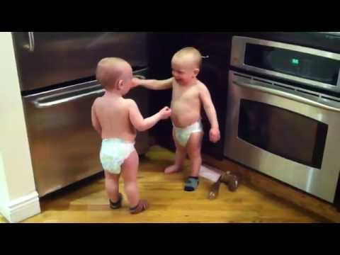

## Glosarioa, semantika eta pragmatika: ariketa

Bilatu hurrengo kontzeptuen definizioa eta euskarazko adibideak aipatu:

- hiponimoa
- hiperonimoa
- sinonimoa
- antonimoa
- homonimoa

### Morfologia eta sintaxia

[figure not shown]

## ¿Qué se controla? ¿La caza en la zona o la zona para cazar?

[figure not shown]

- Morfologiak hitzen barneko egitura aztertzen du.
- Nola bereizten ditugu hitzak morfologikoki?
- izenak, adjektiboak, aditzak, adberbioak, determinatzaileak, izenordainak, partikulak, aditz laguntzaileak, …

## Aztertu hurrengo esaldia morfologikoki:

| Lagunarekin | etorri | nintzen |
| --- | --- | --- |
| Lagun-a-rekin | etor(r)-i | n-in-tze-n |
| Izena-artik.det.-soziatiboa | aditz erroa-aspk. | 1.per-erro.asp-1.per-irg. |

## Euskararen kasua

Hitza maila goreneko unitatea da, morfema unitate minimoena.

Morfema gramatikalak: funtzio gramatikal eta sintaktikoa.

- deklinabidea, artikuluak, etab.
- Morfema lexikalak: erro baten esanahia.
- erro = `etxe`, `edalontzi`, `zoriontasun`, …

Deklinabideak

- Izen-sintagma: kasu gramatikalak
- Leku-denborazko kasuak

## Kasu gramatikalak

- absolutoa: `Ø`  
  *mutil bat dator*
- partitiboa: `-rik`  
  *ez du dirurik*
- ergatiboa: `-k`  
  *neskak jan du*
- datiboa: `-i`  
  *amari eman diot*

## Leku-denborazko kasuak

- inesiboa: `-n`  
  *etxean*, *amarengan*
- leku-genitiboa: `-ko`/`-go`  
  *etxeko*
- adlatiboa: `-tik`, `-ra`, `-rako`, `-raino`, `-rantz`  
  *etxetik*, *amarengandik*; *etxera*, *amarengana*; *etxerako*, *amarenganako*; *etxeraino*, *amarenganaino*; *etxerantz*, *amarenganantz*

## Beste osagarri batzuk

- genitiboa: `-en`  
  *neskaren*
- instrumentala: `-z`  
  *gazteleraz*
- soziatiboa: `-kin`  
  *neskarekin*
- motibatiboa: `-(n)gatik`  
  *neskagatik*
- destinatiboa: `-entzat`  
  *neskarentzat*

[Gehitxuago jakiteko](https://www.hiru.eus/eu/lengua-vasca/sintagmas-de-la-oracion-declinacion)

## Aztertu hurrengo esaldia morfologikoki

Laguntza ariketa hau egiteko, [hemen](http://ixa2.si.ehu.es/demo/analisianali.jsp)

> Amaren etxera noa.

> Atzo ez ginen eskolara etorri.

> Hemen salda dago.

> Medikuarengana joan behar dut.

## Sintaxia

Sintaxiak, berriz, perpausen barneko egitura eta egitura horiek perpausan betetzen duten funtzioa.

[Gehitxuago jakiteko](https://www.ehu.eus/seg/hizk/1/4)

## Glosarioa, morfologia eta sintaxia: ariketa

Bilatu hurrengo kontzeptuen definizioa eta adibideak aipatu:

- izen-sintagma
- aditz-sintagma
- ergatiboa
- komunztadura
- perpausa

### Fonetika eta Fonologia

## Fonologia

Fonemak eta beraien funtzioa aztertzen dituen zientzia. Fonemak unitate linguistiko txikienak dira, ez daukate esanahirik eta abstraktuak dira. Esanahiak bereizteko balio dute: adibidez, *kopa* eta *topa*. `/k/` eta `/t/` ez dute esanahirik, baina bi hitz hauek bereizteko balio dute.

## Fonetika

Fonetikak soinuak/hotsak eta beraien ekoizpena aztertzen dituen zientzia da. Hau da, soinuak nola eratzen diren eta nola hautematen diren. Hotsak fonemen errepresentazio materialak dira.

## Fonemak eta alofonoak…

[figure not shown]

- Pub
- Smirnoff, zer da?
- Nola esango zenuke euskaraz *ha ido allí*?
- Eta gaztelaniaz *nik esan nuen hori atzo*?
- /astekobatbearda/
- /binolauxiliaresaltaier/

[figure not shown]

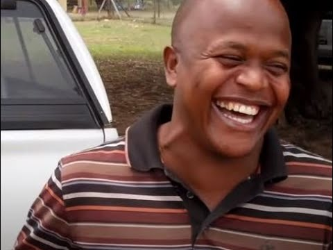

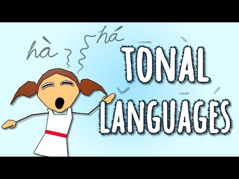

[✈️](https://www.youtube.com/shorts/rFW6iF3sUys)

## Euskararen hotsak

## Bokalak

`/a/` : erdiko bokal ireki edo behekoa

`/e/` : aitzineko bokal erdi-ireki edo artekoa

`/i/` : aitzineko bokal itxi edo goikoa

`/o/` : atzeko bokal erdi-ireki edo artekoa

`/u/` : atzeko bokal itxi edo goikoa

`/y/` : aitzineko bokal biribildu itxi edo goikoa, ortografikoki `ü`z adierazten dena.

## Kontsonanteak

24 fonema kontsonantiko daude. Fonemak honen arabera sailkatzen dira:

- ahots korden ekintza
- sudur/aho barrunbearen arteko bereizketa
- ahoskunea
- ahots moldea

## Glosarioa, fonetika eta fonologia: ariketa

Bilatu hurrengo kontzeptuen definizioa eta euskarazko adibideak aipatu:

- alofonoa
- fonema
- hiatoa
- azentua
- diptongo

# Lehenengo ariketa nagusia

Marraztu hizkuntzaren elementuen jabekuntzaren hurrenkera.

Proposatzen diren testuak: Barreña (2012) eta Garcia et all. (2014).

# Kontzeptuak sendotzeko ariketa

**Alderatu glosategiko elementuen arabera euskara beste hizkuntza batekin:**

https://www.hiru.eus/eu/lengua/semantica (09/10/2018)  
https://prezi.com/0s5igkyblus_/pragmatika/  
https://www.euskara.euskadi.eus/r59-lurconte/eu/contenidos/articulo/c0301/eu_d0301008/0301008.html  
https://ikasmaterialak.ehu.eus/hizkuntza-ikasketak/euskal-fonetika-fonologia/euskal-fonetika-fonologiaren-ikasketarako-gaiak.pdf

**Erreferentziak**

Barreña, A. (2012). Fonologiaren, lexikoaren, morfologiaren eta sintaxiaren garapena haur euskaldunengan. In *Hizkuntzaz jabetzen* (0-6) (Libk. 16, or. 67–107). Mendebalde Kultura Alkartea. http://www.mendebalde.com/modulos/usuariosFtp/conexion/archi524A.pdf

Garcia, I., Barreña, A., Ezeizabarrena, M. J., Almgren, M., Arratibel, N., & Barnes, J. (2014). Haur euskaldunen komunikazio-garapena neurtzen 30-50 hila-bete bitartean: MacArthur-Bates CDI-III tresnaren euskal bertsioa. *Uztaro: giza eta gizarte-zientzien aldizkaria*, *88*, 33–72.

Euskara Institutua, EHU. (2011). Hots motak, euskal soinuak. In *Sareko Euskal Gramatika (SEG)*. https://www.ehu.eus/seg/fon/1/1/1